# Customer segmentation with clustering algorithms.

Instacart is an American company founded in 2012 that operates a grocery delivery and pick-up service in the United States and Canada.

The company offers its services via a website and mobile app. The service allows customers to order groceries from participating retailers with the shopping being done by a personal shopper. Orders are fulfilled and delivered by a personal shopper, who picks, packs, and delivers the order.

Instamarket orders are available in [kaggle](https://www.kaggle.com/psparks/instacart-market-basket-analysis) and contain information about which items were present in each order, as well as which orders belonged to which customers.

With this data, it is possible to analyze the relations between the orders to make business strategies regarding how the customers are treated:

1. Which customers should be grouped together.
2. What are the characteristics these customers have in common and what strategies should be used to best deal with their needs.

```python
from termcolor import cprint
import itertools
import time
import matplotlib.pyplot as plt
import numpy as np
import pandas as pd
pd.set_option('display.max_columns', None)
from sklearn.cluster import MiniBatchKMeans,FeatureAgglomeration,KMeans,Birch,DBSCAN,MeanShift
from sklearn.decomposition import PCA
from sklearn.mixture import GaussianMixture
from sklearn.metrics import silhouette_score, davies_bouldin_score, calinski_harabasz_score
recalculate_customer_department_pctgs=0
recalculate_metrics_kmeans=0
recalculate_metrics_gaussian=0
from collections import Counter
import random
from sklearn.manifold import TSNE

random.seed(1)

recalculate_tsne=0
```

## 1. Data processing

The data was merged together in a table, which contains the product id, as well as the department information of the item bought. Each item belongs to an order id (number of the order), which in turn belongs to a given user id (customer identification number).

```python
orders_users=pd.read_csv('../data/orders.csv')[['user_id','order_id']]

unique_users=len(pd.unique(orders_users['user_id']))
order_products=pd.read_csv('../data/order_products__prior.csv')[['order_id','product_id']]
reassigned_prod_department=pd.read_csv('../processed_data/reassigned_products.csv',index_col=0)
departments=pd.read_csv('../data/departments.csv')

dict_order_users=dict(zip(orders_users['order_id'],orders_users['user_id']))
reassigned_prod_department_dict=dict(zip(reassigned_prod_department['product_id'],reassigned_prod_department['new_department_id']))
dict_departments=dict(zip(departments['department_id'],departments['department']))

#%%

order_products['user_id']=list(map(lambda x:dict_order_users[x],order_products['order_id']))

order_products['department_id']=list(map(lambda x:reassigned_prod_department_dict[x],order_products['product_id']))

order_products['department_name']=list(map(lambda x: dict_departments[x],order_products['department_id']))
# %%
order_products[['order_id','user_id','product_id','department_id','department_name']]
```

|  | order_id | user_id | product_id | department_id | department_name |
| --- | --- | --- | --- | --- | --- |
| 0 | 2 | 202279 | 33120 | 16 | dairy eggs |
| 1 | 2 | 202279 | 28985 | 4 | produce |
| 2 | 2 | 202279 | 9327 | 13 | pantry |
| 3 | 2 | 202279 | 45918 | 13 | pantry |
| 4 | 2 | 202279 | 30035 | 13 | pantry |
| ... | ... | ... | ... | ... | ... |
| 32434484 | 3421083 | 25247 | 39678 | 17 | household |
| 32434485 | 3421083 | 25247 | 11352 | 19 | snacks |
| 32434486 | 3421083 | 25247 | 4600 | 1 | frozen |
| 32434487 | 3421083 | 25247 | 24852 | 4 | produce |
| 32434488 | 3421083 | 25247 | 5020 | 19 | snacks |

32434489 rows × 5 columns

To transform this data to describe customer behavior, all orders were grouped so that, for each customer, a percentage of items bought from a given department is given. This is shown in the table below. As an example, customer number 1 had 22% of all items bought belonging to section "beverages", 5% to breakfast, 3% to household and so on.

Obs: customers that had 20 items bought or less were separated from the data. They were assigned to a group, called the "-1" group. This group is composed of users which were judged to have too few data to be grouped together with other groups.

```python
if recalculate_customer_department_pctgs:
    products_by_user_department=order_products.groupby(['user_id', 'department_name']).agg({'order_id': 'count'})

    products_by_user_department_pctg = products_by_user_department.groupby(level=0).apply(lambda x:100 * x / float(x.sum()))

    products_by_user_department_pctg=products_by_user_department_pctg.rename(columns={'order_id':'pctg_of_user_products'})

    pctg_table=pd.pivot_table(products_by_user_department_pctg.reset_index(),values='pctg_of_user_products',columns='department_name',index='user_id')

    #filtering only customers with more than 20 items bought
    products_bought_by_customer=order_products.groupby('user_id').count()[['order_id']].rename(columns={'order_id':'products_bought'}).reset_index()
    customers_filtered=products_bought_by_customer[products_bought_by_customer['products_bought']>20]['user_id']
    pctg_table=pctg_table.loc[customers_filtered,:]


    pctg_table.to_csv('../processed_data/customer_department_pctg.csv')
pctg_table=pd.read_csv('../processed_data/customer_department_pctg.csv')
unique_users_after_filter=len(pd.unique(pctg_table['user_id']))

pctg_table=pctg_table.fillna(0).set_index('user_id')
pctg_table
```

| user_id | alcohol | babies | bakery | beverages | breakfast | bulk | canned goods | dairy eggs | deli | dry goods pasta | frozen | household | international | meat seafood | pantry | personal care | pets | produce | snacks |
| --- | --- | --- | --- | --- | --- | --- | --- | --- | --- | --- | --- | --- | --- | --- | --- | --- | --- | --- | --- |
| 1 | 0.0 | 0.000000 | 0.000000 | 22.033898 | 5.084746 | 0.0 | 0.000000 | 22.033898 | 0.000000 | 0.000000 | 0.000000 | 3.389831 | 0.000000 | 0.000000 | 1.694915 | 0.000000 | 0.000000 | 8.474576 | 37.288136 |
| 2 | 0.0 | 0.000000 | 1.025641 | 4.615385 | 1.538462 | 0.0 | 0.512821 | 24.615385 | 10.769231 | 0.000000 | 8.717949 | 0.000000 | 1.538462 | 0.512821 | 5.641026 | 0.512821 | 0.000000 | 18.461538 | 21.538462 |
| 3 | 0.0 | 0.000000 | 0.000000 | 3.409091 | 0.000000 | 0.0 | 0.000000 | 23.863636 | 2.272727 | 4.545455 | 6.818182 | 1.136364 | 0.000000 | 0.000000 | 4.545455 | 0.000000 | 0.000000 | 43.181818 | 10.227273 |
| 5 | 0.0 | 0.000000 | 0.000000 | 0.000000 | 0.000000 | 0.0 | 2.702703 | 21.621622 | 2.702703 | 2.702703 | 5.405405 | 0.000000 | 5.405405 | 0.000000 | 5.405405 | 0.000000 | 0.000000 | 51.351351 | 2.702703 |
| 7 | 0.0 | 0.000000 | 2.427184 | 24.757282 | 0.000000 | 0.0 | 2.912621 | 15.533981 | 6.310680 | 0.000000 | 1.941748 | 0.485437 | 0.000000 | 3.883495 | 4.368932 | 0.000000 | 0.485437 | 27.669903 | 9.223301 |
| ... | ... | ... | ... | ... | ... | ... | ... | ... | ... | ... | ... | ... | ... | ... | ... | ... | ... | ... | ... |
| 206205 | 0.0 | 3.125000 | 6.250000 | 3.125000 | 0.000000 | 0.0 | 0.000000 | 43.750000 | 9.375000 | 0.000000 | 6.250000 | 0.000000 | 0.000000 | 3.125000 | 0.000000 | 0.000000 | 0.000000 | 25.000000 | 0.000000 |
| 206206 | 0.0 | 0.000000 | 0.701754 | 11.578947 | 0.350877 | 0.0 | 3.157895 | 13.684211 | 1.754386 | 0.350877 | 26.666667 | 4.561404 | 1.403509 | 0.701754 | 4.912281 | 3.508772 | 0.000000 | 11.929825 | 14.736842 |
| 206207 | 0.0 | 0.448430 | 1.345291 | 8.968610 | 1.793722 | 0.0 | 4.932735 | 23.318386 | 3.587444 | 3.587444 | 9.417040 | 0.000000 | 0.448430 | 2.690583 | 6.726457 | 0.000000 | 0.000000 | 22.421525 | 10.313901 |
| 206208 | 0.0 | 0.443131 | 9.158050 | 2.954210 | 2.511078 | 0.0 | 1.624815 | 23.929099 | 4.135894 | 2.511078 | 3.840473 | 0.886263 | 0.443131 | 3.249631 | 5.612999 | 0.738552 | 0.000000 | 29.246677 | 8.714919 |
| 206209 | 0.0 | 0.000000 | 6.976744 | 7.751938 | 6.976744 | 0.0 | 5.426357 | 21.705426 | 4.651163 | 2.325581 | 1.550388 | 10.852713 | 0.775194 | 1.550388 | 6.201550 | 0.000000 | 0.000000 | 14.728682 | 8.527132 |

185235 rows × 19 columns

## 2.1 Data reduction with PCA

There were a total of 19 features and we want to group customers together based on these 19 features. As there is a lot of correlation between the features and some features may be redundant or insignificant in the customer behavior, a data reduction is interesting. Data reduction consists in reducing the existing features into a lower number of features to make the data visualization easier as well as remove redundant information from the data.

First, a principal component analysis (PCA) is performed. The aim of PCA is to reduce the dimensionality by projecting each data point on a lower dimensional domain. This domain is the one responsible for explaining most of the variance in the data: In other words, most of the behaviour of the data points can be explained using less features (instead of using 19 features, it is possible to use less features and make the upcoming models easier to be trained)

This is shown in the figure below: The first component explains 40% of the variance associated to the 19 original features. The 10 first components of the PCA are responsible for explaining more than 90% of the variance of the original features. From now on, this 10 features subdomain is going to be used.

```python
X=pctg_table

pca = PCA()
x_pca = pca.fit_transform(X)

data_reduced=pd.DataFrame(x_pca)[np.arange(0,10)]

explained_variance = pca.explained_variance_ratio_
```

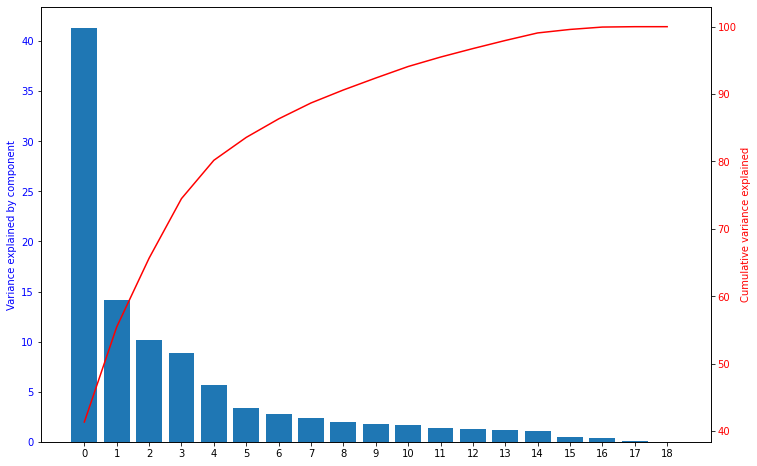

```python
fig,ax1=plt.subplots(1,1,figsize=(12,8))
ax1.bar(np.arange(len(explained_variance)),explained_variance*100)
ax1.set_xticks(np.arange(len(explained_variance)))
ax2=ax1.twinx()
ax2.plot(np.arange(len(explained_variance)),np.cumsum(explained_variance)*100,color='r')
ax1.tick_params(axis='y', labelcolor='b')
ax2.tick_params(axis='y', labelcolor='r')
ax1.set_ylabel('Variance explained by component',color='b')
ax2.set_ylabel('Cumulative variance explained',color='r')
plt.show()
```

## 2.2 Data reduction with T-SNE

The features were reduced from a 19D space down to a 10D space. This was done using PCA, which is a not so computationally expensive method. As the method is linear, it also cannot represent complex relations between features.

The t-SNE algorithm provides an method to visualize complex high-dimensional datasets. A t-SNE algorithm was used to reduce the data from 10D to a 3D domain, composed of 3 components. The first 2 components are shown in the figure below.

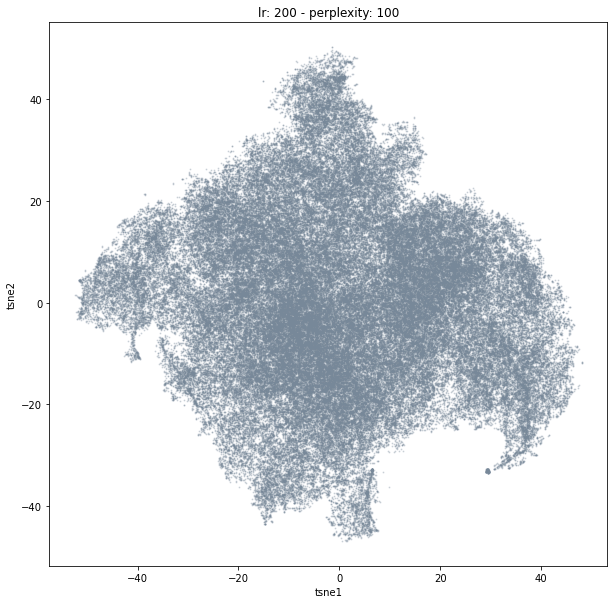

```python
perp=100
lr=200
if recalculate_tsne:

    tsne=TSNE(n_components=3,verbose=0, perplexity=perp,n_iter=5000,learning_rate=lr)
    tsne_scale_results=tsne.fit_transform(data_reduced)
    data_reduced_tsne=pd.DataFrame(tsne_scale_results,columns=['tse1','tse2','tse3'])

    data_reduced_tsne.to_csv('../processed_data/data_tsne.csv')
else:
    data_reduced_tsne=pd.read_csv('../processed_data/data_tsne.csv',index_col=0)
#%%
plt.figure(figsize = (10,10))
plt.scatter(data_reduced_tsne.iloc[:,0],data_reduced_tsne.iloc[:,1],alpha=0.25, facecolor='lightslategray',s=1)
plt.xlabel('tsne1')
plt.ylabel('tsne2')
plt.title('lr: {} - perplexity: {}'.format(lr,perp))
plt.savefig('./tsne_images/lr_{:.1f}_perp_{:.1f}.jpg'.format(lr,perp),dpi=200)
```

## 3. Clustering data

Now that the data was reduced down to 3 dimensions, it is time to use the distribution in these dimensions to group customers together. Two different clustering algorithms are used: kmeans and gaussian mixture.

## 3.1 Clustering with k-means

K-means is a non supervised algorithm (no need of external labeled inputs) that clusters data points together based on the similarity to other points. Based on a selected "k" number of clusters selected, it divides the domain in "k" groups.

By using distance between the center of the group and the points belonging to the group, the algorithm calculates the SSE (sum of squared errors), trying to minimize it's value.

As an example, a k-means algorithm with 6 clusters is trained on the data. The algorithm divides the data into 6 groups, as shown below.

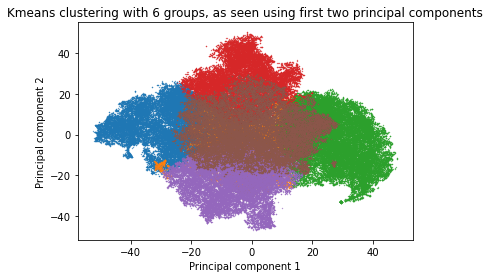

```python
data_pred=data_reduced_tsne

model = MiniBatchKMeans(n_clusters=6)
model.fit(data_pred)
model_labels=model.labels_
yhat=model.predict(data_pred)

data_pred['pred']=yhat
data=pctg_table.copy()
data['pred']=yhat

clusters = pd.unique(yhat)

for cluster in clusters:
	# get row indexes for samples with this cluster
	subset = data_pred[data_pred['pred'] == cluster]
	# create scatter of these samples
	plt.scatter(subset['tse1'], subset['tse2'],s=0.1)
plt.xlabel('Principal component 1')
plt.ylabel('Principal component 2')
plt.title('Kmeans clustering with 6 groups, as seen using first two principal components')
plt.show()
```

## 3.2 Ideal number of groups with k-means

To arrive at the ideal number of groups, two scores were used: silhouette and davies-bouldin.

The idea is to iterate the k-means algorithm using different numbers of clusters. The best number is the one that maximizes the silhouette score and minimizes the davies-boulding score.

From the plots below, it is clear that 5-clusters achieve this: There is a clear elbow for the davies-boulding score at 5 groups where there is not much more reduction to the score.

**1. Silhouette score (SWC)**

$$SWC=\frac{\sum\frac{(b(i)-a(i))}{max(a(i),b(i))}}{N} $$

Where:

a(i) - average dissimilarity of i th object to its clusters

b(i) - average dissimilarity of i th object to the nearest neighbor cluster.

By maximizing the dissimilarity to the neighbor clusters (b) and minimizing the dissimilarity to the own cluster (a), and thus maximizing the SWC, the better the performance is. With a higher number of clusters, the lower are both a(i) and b(i)

**2. Davies Bouldin index (DB)**

The DB index tries to minimize the distance between the datapoints and the cluster center while, at the same time, maximizing the distance between cluster centers.

```python
kmeans_kwargs = {"init": "random",
    "n_init": 10,
    "max_iter": 300,
    "random_state": 42,}
recalculate_metrics_kmeans=0
if recalculate_metrics_kmeans:

    #n_init - > Number of time the k-means algorithm will be run with different centroid seeds. The final results will be the best output of n_init consecutive runs in terms of inertia.
    sse=[]
    silhouette_coefficients = []
    db_scores=[]
    ch_scores=[]
    #cluster_algorithm
    for k in range(2,15):
        print(k)
        model = KMeans(n_clusters=k,**kmeans_kwargs)
        model.fit(data_pred)
        model_labels=model.labels_
        sse.append(model.inertia_)
        score = silhouette_score(data_pred, model_labels)
        silhouette_coefficients.append(score)
        db_scores.append(davies_bouldin_score(data_pred,model_labels))
        ch_scores.append(calinski_harabasz_score(data_pred,model_labels))
    ################

    metrics_kmeans=pd.DataFrame(zip(*[list(range(2,15)),sse,silhouette_coefficients,db_scores,ch_scores]),columns=['clusters','sse','silhouette','davies_bouldin','calinski_harabasz_score'])
    metrics_kmeans.to_excel('../processed_data/metrics_kmeans.xlsx')
else:
    metrics_kmeans=pd.read_excel('../processed_data/metrics_kmeans.xlsx',index_col=0)
```

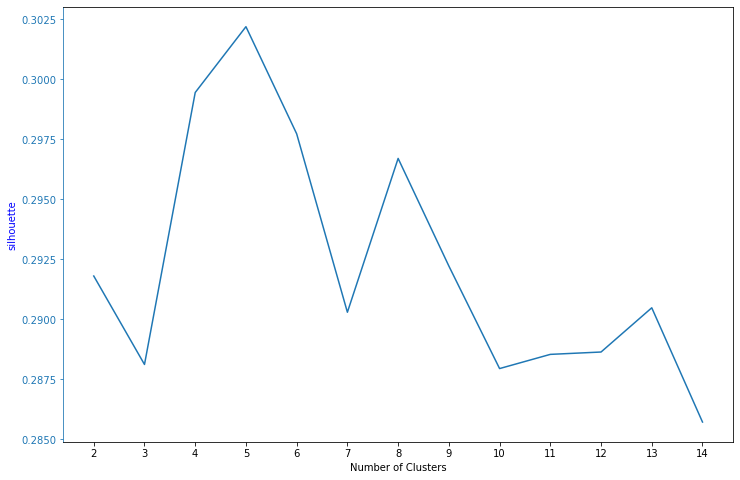

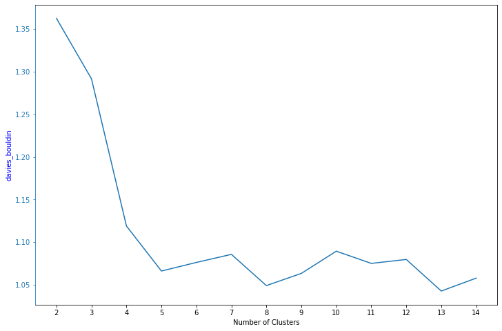

```python
# Plotting metrics for different number of clusters used. Try to identify which number of clusters is the best
#measures=['sse','silhouette','davies_bouldin','calinski_harabasz_score']
measures=['silhouette','davies_bouldin']
for measure in measures:
    metric=metrics_kmeans[measure]
    metricdiff = [(metric[n-1]-metric[n])/(metric[n]-metric[n+1]) for n in range(1,len(metric)-1)]
    fig,ax1=plt.subplots(figsize=(12,8))
    p1,=ax1.plot(metrics_kmeans['clusters'], metric,label=measure)
    ax1.set_xticks(metrics_kmeans['clusters'])
    ax1.set_xlabel("Number of Clusters")
    ax1.tick_params(axis='y', colors=p1.get_color())

    ax1.set_ylabel(measure,color='blue')
    ax1.spines["left"].set_edgecolor(p1.get_color())

    if measure in ['davies_bouldin','silhouette']:continue
    ax2=ax1.twinx()
    p2,=ax2.plot(metrics_kmeans['clusters'][1:-1], metricdiff,'red',label='Delta J - {}'.format(measure))
    lines = [p1, p2]
    ax1.legend(lines, [l.get_label() for l in lines])


    ax2.set_ylabel('Delta J - {}'.format(measure),color='red')
    ax2.tick_params(axis='y', colors=p2.get_color())
    ax2.spines["right"].set_edgecolor(p2.get_color())
```

## 3.3 Studying the clusters obtained through k-means

The algorithm was ran using 5 groups. As mentioned in section 1, a 6th group (named "-1") was created for customers with too few items bought.

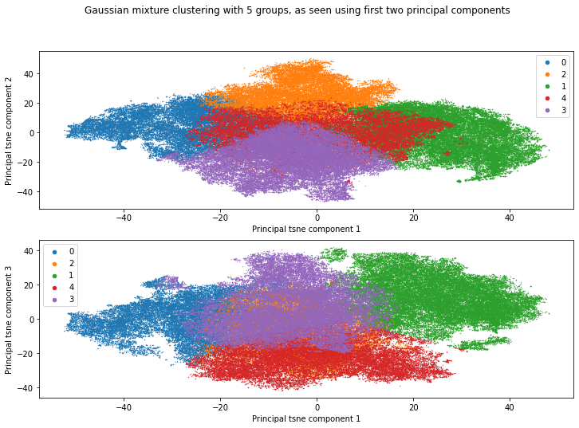

```python
#Using model with ideal number of clusters, which were chosen based on metrics plots
groups=5
model = KMeans(n_clusters=groups,**kmeans_kwargs)
model.fit(data_pred)
model_labels=model.labels_
#building a dictionary associating customers to cluster group
customer_segmentation_dict=dict(zip(list(pctg_table.index),model_labels))
#assigning customers to groups
order_products['customer_group']=list(map(lambda x: customer_segmentation_dict[x] if x in customer_segmentation_dict else -1,order_products['user_id']))
data_pred['pred']=model_labels


fig,axs=plt.subplots(2,1,figsize=(12,8))
for cluster in pd.unique(data_pred['pred']):
	# get row indexes for samples with this cluster
	subset = data_pred[data_pred['pred'] == cluster]
	# create scatter of these samples
	axs[0].scatter(subset['tse1'], subset['tse2'],label=str(cluster),s=0.1)
leg=axs[0].legend()

for i in np.arange(len(leg.legendHandles)):
    leg.legendHandles[i]._sizes =[20]

axs[0].set_xlabel('Principal tsne component 1')
axs[0].set_ylabel('Principal tsne component 2')
fig.suptitle('Gaussian mixture clustering with {} groups, as seen using first two principal components'.format(groups))

for cluster in pd.unique(data_pred['pred']):
	# get row indexes for samples with this cluster
	subset = data_pred[data_pred['pred'] == cluster]
	# create scatter of these samples
	axs[1].scatter(subset['tse1'], subset['tse3'],label=str(cluster),s=0.1)
leg=axs[1].legend()

for i in np.arange(len(leg.legendHandles)):
    leg.legendHandles[i]._sizes =[20]

axs[1].set_xlabel('Principal tsne component 1')
axs[1].set_ylabel('Principal tsne component 3')
```

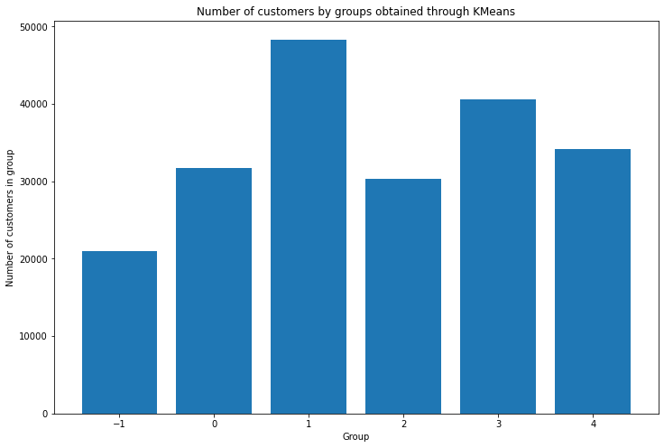

```python
def plot_customers_by_group(model_labels,model_name):
    '''
    Plots the total number of items bought by customer cluster.

    Input:
        model_labels - list of cluster numbers, each item is equivalent to a given customer.
        model_name - name of the clustering alogrithm used
    '''

    groups=[-1]+list(Counter(model_labels).keys())

    #Plotting number of customers that belong to each cluster
    count_by_group=[unique_users-unique_users_after_filter]+list(Counter(model_labels).values())
    plt.figure(figsize=(12,8))
    plt.bar(groups,count_by_group)
    plt.xlabel('Group')
    plt.ylabel('Number of customers in group')
    plt.title('Number of customers by groups obtained through {}'.format(model_name))

plot_customers_by_group(model_labels, 'KMeans')

def plot_items_by_dep_and_customer_group():
    '''
    Plots the percentage of items by department bought by each customer group. Helps in identifying

    Uses the current prediction, present in the "customer_group" column of the order_products table
    '''

    # Getting items bought by department, grouped by customer cluster. Plot how much participation each cluster got in each department
    customer_group_product_count = (order_products.groupby(['department_name','customer_group'])['order_id'].count()/order_products.groupby(['department_name'])['order_id'].count()).reset_index()

    pivot_table_kmeans=pd.pivot_table(customer_group_product_count,index='department_name',columns='customer_group',values='order_id')
    pivot_table_kmeans=pivot_table_kmeans*100
    pivot_table_kmeans.plot(kind='bar',stacked=True,figsize=(12,8))
    plt.title('Percentage of department items bought by customer group')
    plt.ylabel('% bought by group')

#plot_items_by_dep_and_customer_group()
```

Finally, the a priori and a posteriori probabilities of a customer buying an item of a certain department are studied in the table (which shows the probability percentage that a customer will buy an item from this category) and figure below:

The grey bar represents the a priori probability: this is the probability that a given item will be bought, regardless of the customer class.

The other bars are the a posteriori probability: Given that the customer belongs to a certain group, these are the probability that the customer bought an item from this category.

As an example, a customer chosen at random has a 0.5% probability of buying an item from the alcohol department. A customer from group 4 has a 2.3% chance of buying alcohol.

Other conclusions that could be taken from the data:

1. Customers from group 4 are much more likely to buy from departments "alcohol", "household", "pets" and "personal care".
2. Customers from group 2 are more likely to buy from "babies".
3. Customers from group 0 are more likely to buy from "produce" and "bulk".
4. Customers from group 1 are more likely to buy from "beverages" and "snack".
5. Customers from group 3 don't have many differences to the "any" segmentation (segmentation with all customers).
6. Customers from group -1 (less than 20 items bought) bought more "alcohol", "beverages" and "household" items.

| customer_group | alcohol | babies | bakery | beverages | breakfast | bulk | canned goods | dairy eggs | deli | dry goods pasta | frozen | household | international | meat seafood | pantry | personal care | pets | produce | snacks |
| --- | --- | --- | --- | --- | --- | --- | --- | --- | --- | --- | --- | --- | --- | --- | --- | --- | --- | --- | --- |
| -1 | 0.021432 | 0.005410 | 0.030365 | 0.144494 | 0.021868 | 0.000951 | 0.023631 | 0.134796 | 0.025968 | 0.015631 | 0.065067 | 0.047193 | 0.005279 | 0.021091 | 0.061217 | 0.024484 | 0.003523 | 0.246047 | 0.101553 |
| 0 | 0.000517 | 0.006351 | 0.024216 | 0.048720 | 0.013120 | 0.001578 | 0.033064 | 0.131975 | 0.027048 | 0.021829 | 0.044482 | 0.013473 | 0.008103 | 0.022358 | 0.053918 | 0.008520 | 0.000779 | 0.484161 | 0.055788 |
| 1 | 0.002964 | 0.007861 | 0.035307 | 0.201965 | 0.025108 | 0.000918 | 0.025462 | 0.136830 | 0.034273 | 0.021127 | 0.066642 | 0.026506 | 0.007785 | 0.017504 | 0.054228 | 0.017961 | 0.003975 | 0.182156 | 0.131428 |
| 2 | 0.002638 | 0.023351 | 0.047477 | 0.049615 | 0.024716 | 0.000926 | 0.041424 | 0.225908 | 0.036375 | 0.034846 | 0.065150 | 0.019090 | 0.009870 | 0.025628 | 0.073457 | 0.011670 | 0.002333 | 0.237606 | 0.067920 |
| 3 | 0.000739 | 0.011482 | 0.034848 | 0.058152 | 0.020845 | 0.001186 | 0.029987 | 0.175693 | 0.034862 | 0.026520 | 0.089999 | 0.011874 | 0.008050 | 0.021509 | 0.050063 | 0.009418 | 0.001430 | 0.314144 | 0.099201 |
| 4 | 0.023647 | 0.021236 | 0.046895 | 0.097840 | 0.031915 | 0.000392 | 0.035621 | 0.174945 | 0.031109 | 0.031868 | 0.084635 | 0.057480 | 0.007995 | 0.021632 | 0.062308 | 0.029885 | 0.009562 | 0.120035 | 0.111000 |
| Any | 0.004915 | 0.013212 | 0.036314 | 0.083202 | 0.021909 | 0.001077 | 0.032967 | 0.167478 | 0.032450 | 0.026735 | 0.069184 | 0.022892 | 0.008330 | 0.021882 | 0.057950 | 0.014072 | 0.003040 | 0.293240 | 0.089153 |

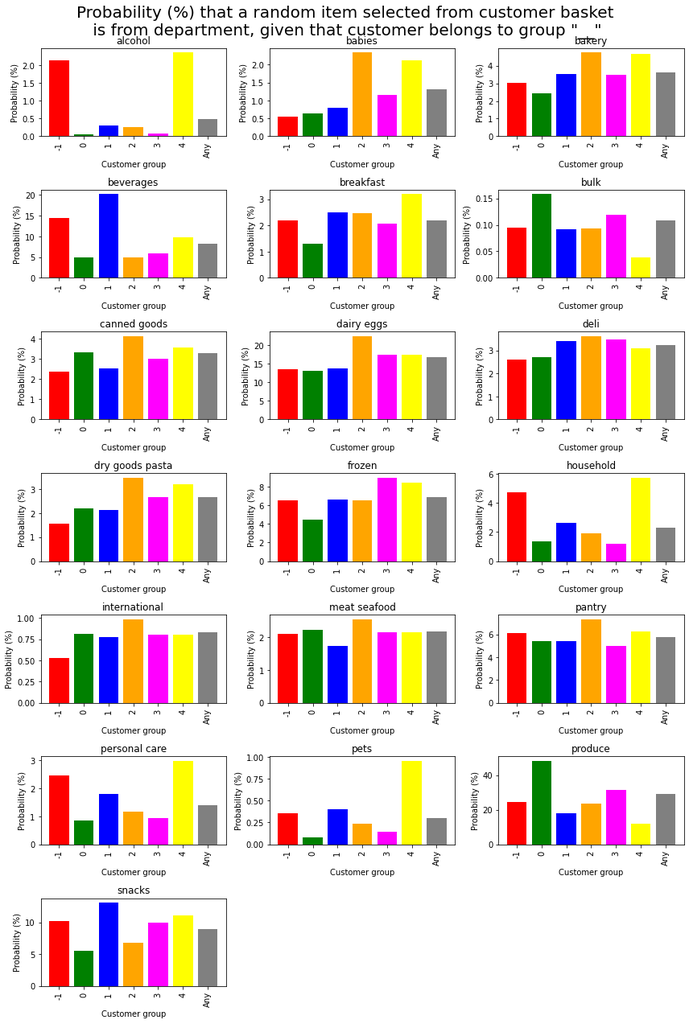

```python
def get_probabilities_given_group():
    '''
    Given customer groups predicted by the clustering algorithm (Present in the "customer_group" column of the order_products table):
    1) Plots the a posteriori probability that a given item belongs to a department, given that the customer which bought the item belongs to cluster ___
    2) Returns the table with the a posteriori probability of the item belong to a customer, given that the customer which bought the item belongs to cluster ___.
    '''
    # Getting items bought by customer cluster, grouped by department.
    customer_group_product_count = (order_products.groupby(['customer_group','department_name'])['order_id'].count()/order_products.groupby(['customer_group'])['order_id'].count()).reset_index()

    #getting items bought by department as a percentage of total items. This will later be added to the table
    total_pctg_by_dep=(order_products.groupby(['department_name'])['order_id'].count()/order_products['order_id'].count()).reset_index()
    total_row=dict(zip(total_pctg_by_dep['department_name'],total_pctg_by_dep['order_id']))
    total_row['customer_group']='Any'

    #getting likelihood of an item given it belongs to a given group
    pivot_table_by_customer_group=pd.pivot_table(customer_group_product_count,index='customer_group',columns='department_name',values='order_id').reset_index().rename_axis(None,axis=1)

    #appending a row represent likelihood with no "a priori" condition
    pivot_table_by_customer_group=pivot_table_by_customer_group.append(total_row,ignore_index=True)
    pivot_table_by_customer_group=pivot_table_by_customer_group.set_index('customer_group')
    #showing table
    pivot_table_by_customer_group
    #%%
    #Ploting probability a posteriori that an item belongs to a department, given the customer cluster to which the customer belongs.
    columns=pivot_table_by_customer_group.columns
    my_colors = ['red', 'green', 'blue', 'orange','magenta','yellow','grey','saddlebrown','black']
    fig,axs=plt.subplots(7,3,figsize=(12,18))
    axs=axs.reshape(-1)
    i=0
    for col in columns:
        y_values=pivot_table_by_customer_group[col]
        axs[i].bar(np.arange(0,len(y_values)),100*y_values,color=my_colors)
        axs[i].set_xticks(np.arange(0,len(y_values)))

        axs[i].set_xticklabels(pivot_table_by_customer_group.index,rotation=90)
        axs[i].set_title(col)
        axs[i].set_ylabel('Probability (%)')
        axs[i].set_xlabel('Customer group')

        i+=1
    while i<21:
        axs[i].spines['top'].set_visible(False)
        axs[i].spines['right'].set_visible(False)
        axs[i].spines['left'].set_visible(False)
        axs[i].spines['right'].set_visible(False)
        axs[i].set_visible(False)
        axs[i].get_xaxis().tick_bottom()
        axs[i].get_yaxis().tick_left()
        i+=1
    plt.suptitle('Probability (%) that a random item selected from customer basket\n is from department, given that customer belongs to group "__"',size=20)
    plt.tight_layout()
    return pivot_table_by_customer_group
t=get_probabilities_given_group()
t
```

By using the a priori and a posteriori probabilities it is also possible to calculate the group "lift" regarding each department.

Lift can be seen as how much the probability of a customer choosing an item given it belongs to a certain group. As an example, there is a probability of 0.5% that any customer buys an item from the "alcohol" category. On the other hand, if the customer belongs to group 4, there is a probability of 2.36% of buying the item. In other words, there is a lift equal to 2.36/0.5=4.8.

The lift table is shown below.

```python
t/t.iloc[-1]
```

| customer_group | alcohol | babies | bakery | beverages | breakfast | bulk | canned goods | dairy eggs | deli | dry goods pasta | frozen | household | international | meat seafood | pantry | personal care | pets | produce | snacks |
| --- | --- | --- | --- | --- | --- | --- | --- | --- | --- | --- | --- | --- | --- | --- | --- | --- | --- | --- | --- |
| -1 | 4.360801 | 0.409473 | 0.836183 | 1.736666 | 0.998125 | 0.883007 | 0.716823 | 0.804857 | 0.800244 | 0.584646 | 0.940488 | 2.061611 | 0.633735 | 0.963879 | 1.056379 | 1.739950 | 1.158876 | 0.839063 | 1.139087 |
| 0 | 0.105231 | 0.480691 | 0.666842 | 0.585565 | 0.598846 | 1.465762 | 1.002968 | 0.788015 | 0.833533 | 0.816466 | 0.642959 | 0.588545 | 0.972672 | 1.021766 | 0.930426 | 0.605481 | 0.256145 | 1.651072 | 0.625761 |
| 1 | 0.603046 | 0.594991 | 0.972267 | 2.427401 | 1.146019 | 0.852854 | 0.772344 | 0.817003 | 1.056195 | 0.790234 | 0.963265 | 1.157889 | 0.934577 | 0.799922 | 0.935783 | 1.276411 | 1.307545 | 0.621184 | 1.474181 |
| 2 | 0.536729 | 1.767487 | 1.307384 | 0.596321 | 1.128131 | 0.859771 | 1.256550 | 1.348881 | 1.120948 | 1.303350 | 0.941688 | 0.833944 | 1.184776 | 1.171212 | 1.267599 | 0.829361 | 0.767539 | 0.810278 | 0.761840 |
| 3 | 0.150322 | 0.869112 | 0.959626 | 0.698928 | 0.951420 | 1.101922 | 0.909610 | 1.049053 | 1.074335 | 0.991926 | 1.300863 | 0.518706 | 0.966317 | 0.982942 | 0.863900 | 0.669264 | 0.470339 | 1.071285 | 1.112705 |
| 4 | 4.811356 | 1.607392 | 1.291355 | 1.175937 | 1.456721 | 0.364479 | 1.080533 | 1.044584 | 0.958682 | 1.191968 | 1.223330 | 2.510959 | 0.959720 | 0.988586 | 1.075215 | 2.123769 | 3.145220 | 0.409339 | 1.245057 |
| Any | 1.000000 | 1.000000 | 1.000000 | 1.000000 | 1.000000 | 1.000000 | 1.000000 | 1.000000 | 1.000000 | 1.000000 | 1.000000 | 1.000000 | 1.000000 | 1.000000 | 1.000000 | 1.000000 | 1.000000 | 1.000000 | 1.000000 |

## 4.1 Clustering with gaussian mixture

Gaussian mixture models are probabilistic models responsible for clustering points together by assuming all the data points are generated from a mixture of gaussian distributions with unknown parameters.

The gaussian distributions can have many shapes, not limiting the groups to have a spherical like shape such as in k-means. One example of how these distribution shapes are is shown in the figure below.

[figure not shown]

## 4.2 Ideal number of clusters with gaussian mixture models.

Similarly to before, multiple numbers of groups were tested.

The best group is the one that maximizes the log likelihood of the groups and maximizes the silhouette. From the figures below, it is obvious the log-likelihood has an elbow at clusters=6. The silhouette also has a peak at clusters=6.

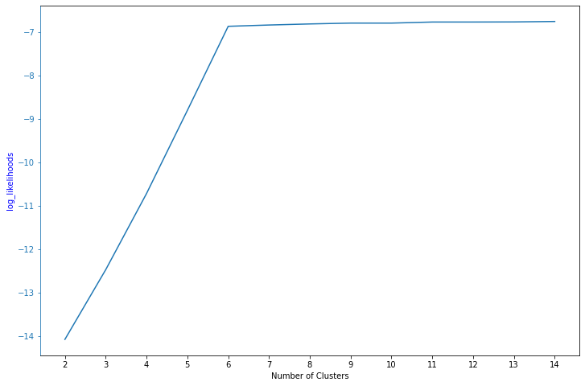

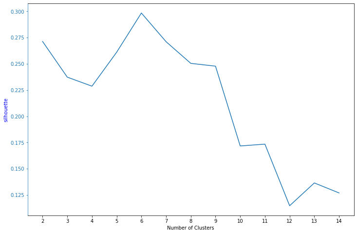

```python
recalculate_metrics_gaussian=0
if recalculate_metrics_gaussian:
    silhouette_coefficients = []
    log_likelihoods=[]
    db_scores=[]
    ch_scores=[]
    aic=[]
    bic=[]
    #cluster_algorithm
    for k in range(2,15):
        print(k)
        model = GaussianMixture(n_components=k)
        model.fit(data_pred)
        log_likelihoods.append(model.lower_bound_)
        model_labels=model.predict(data_pred)
        aic.append(model.aic(data_pred))
        bic.append(model.bic(data_pred))
        score = silhouette_score(data_pred, model_labels)
        silhouette_coefficients.append(score)
        db_scores.append(davies_bouldin_score(data_pred,model_labels))
        ch_scores.append(calinski_harabasz_score(data_pred,model_labels))
    metrics_gaussian_mix=pd.DataFrame(zip(*[list(range(2,15)),log_likelihoods,silhouette_coefficients,db_scores,ch_scores]),columns=['clusters','log_likelihoods','silhouette','davies_bouldin','calinski_harabasz_score'])
    metrics_gaussian_mix.to_excel('../processed_data/metrics_gaussian_mix.xlsx')
else:
    metrics_gaussian_mix=pd.read_excel('../processed_data/metrics_gaussian_mix.xlsx',index_col=0)
# Plotting metrics for different number of clusters used. Try to identify which number of clusters is the best
for measure in ['log_likelihoods','silhouette']:
    metric=metrics_gaussian_mix[measure]
    metricdiff = [(metric[n-1]-metric[n])/(metric[n]-metric[n+1]) for n in range(1,len(metric)-1)]
    fig,ax1=plt.subplots(figsize=(12,8))
    p1,=ax1.plot(metrics_gaussian_mix['clusters'], metric,label=measure)
    ax1.set_xticks(metrics_gaussian_mix['clusters'])
    ax1.set_xlabel("Number of Clusters")
    ax1.tick_params(axis='y', colors=p1.get_color())

    ax1.set_ylabel(measure,color='blue')
    ax1.spines["left"].set_edgecolor(p1.get_color())

    if measure in ['davies_bouldin','silhouette','log_likelihoods']:continue
    ax2=ax1.twinx()
    p2,=ax2.plot(metrics_gaussian_mix['clusters'][1:-1], metricdiff,'red',label='Delta J - {}'.format(measure))
    lines = [p1, p2]
    ax1.legend(lines, [l.get_label() for l in lines])


    ax2.set_ylabel('Delta J - {}'.format(measure),color='red')
    ax2.tick_params(axis='y', colors=p2.get_color())
    ax2.spines["right"].set_edgecolor(p2.get_color())
```

## 4.3 Studying the clusters obtained through gaussian mixture

The algorithm was ran using 6 groups. As mentioned in section 1, a 7th group (named "-1") was created for customers with too few items bought.

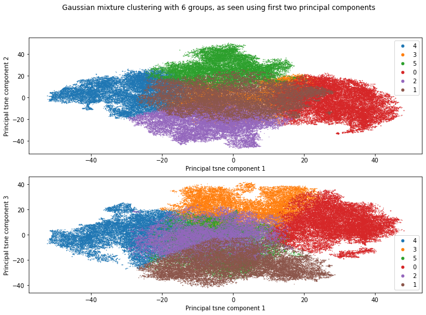

```python
#Using model with ideal number of clusters, which were chosen based on metrics plots
groups=6
model = GaussianMixture(n_components=groups)
model.fit(data_pred)
yhat=model.predict(data_pred)


data_pred['pred']=yhat

clusters = pd.unique(yhat)

fig,axs=plt.subplots(2,1,figsize=(12,8))
for cluster in clusters:
	# get row indexes for samples with this cluster
	subset = data_pred[data_pred['pred'] == cluster]
	# create scatter of these samples
	axs[0].scatter(subset['tse1'], subset['tse2'],label=str(cluster),s=0.1)
leg=axs[0].legend()

for i in np.arange(len(leg.legendHandles)):
    leg.legendHandles[i]._sizes =[20]

axs[0].set_xlabel('Principal tsne component 1')
axs[0].set_ylabel('Principal tsne component 2')
fig.suptitle('Gaussian mixture clustering with {} groups, as seen using first two principal components'.format(groups))

for cluster in clusters:
	# get row indexes for samples with this cluster
	subset = data_pred[data_pred['pred'] == cluster]
	# create scatter of these samples
	axs[1].scatter(subset['tse1'], subset['tse3'],label=str(cluster),s=0.1)
leg=axs[1].legend()

for i in np.arange(len(leg.legendHandles)):
    leg.legendHandles[i]._sizes =[20]

axs[1].set_xlabel('Principal tsne component 1')
axs[1].set_ylabel('Principal tsne component 3')

customer_segmentation_dict_gaussian=dict(zip(list(pctg_table.index),yhat))
order_products['customer_group']=list(map(lambda x: customer_segmentation_dict_gaussian[x] if x in customer_segmentation_dict_gaussian else -1,order_products['user_id']))
```

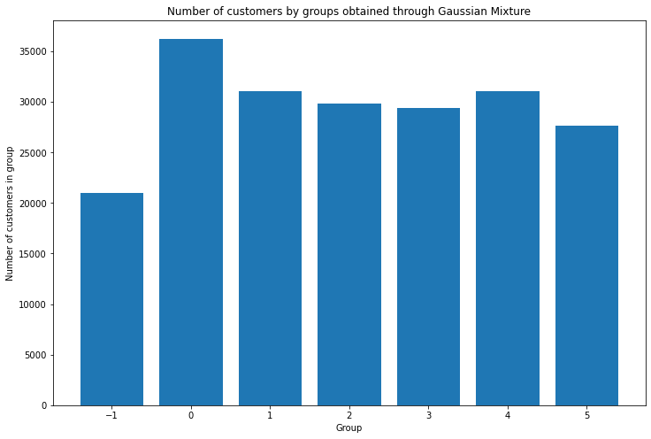

```python
plot_customers_by_group(yhat,'Gaussian Mixture')
```

Similar to the previous section, which used kmeans to obtain the groups, a similar study of the a priori and a posteriori probabilities is made.

The main conclusions:

1. Customers from group 0 are more likely to buy from "produce" and "bulk".
2. Customers from group 5 are much more likely to buy from departments "alcohol", "household", "pets" and "personal care".
3. Customers from group 1 are more likely to buy from "babies".
4. Customers from group 4 are more likely to buy from "beverages" and "snack".
5. Customers from groups 2 and 3 don't have many differences to the "any" segmentation (segmentation with all customers).

Overall, the customer distribution was very similar to the distribution obtained using kmeans.

| customer_group | alcohol | babies | bakery | beverages | breakfast | bulk | canned goods | dairy eggs | deli | dry goods pasta | frozen | household | international | meat seafood | pantry | personal care | pets | produce | snacks |
| --- | --- | --- | --- | --- | --- | --- | --- | --- | --- | --- | --- | --- | --- | --- | --- | --- | --- | --- | --- |
| -1 | 0.021432 | 0.005410 | 0.030365 | 0.144494 | 0.021868 | 0.000951 | 0.023631 | 0.134796 | 0.025968 | 0.015631 | 0.065067 | 0.047193 | 0.005279 | 0.021091 | 0.061217 | 0.024484 | 0.003523 | 0.246047 | 0.101553 |
| 0 | 0.000622 | 0.005597 | 0.023453 | 0.051749 | 0.011686 | 0.001604 | 0.036613 | 0.105557 | 0.026756 | 0.022336 | 0.046592 | 0.016096 | 0.008839 | 0.023139 | 0.059354 | 0.009481 | 0.000951 | 0.502139 | 0.047437 |
| 1 | 0.002906 | 0.024354 | 0.045922 | 0.050332 | 0.025422 | 0.000865 | 0.043523 | 0.229528 | 0.033711 | 0.035746 | 0.064209 | 0.021320 | 0.010046 | 0.025954 | 0.077420 | 0.012464 | 0.002694 | 0.225516 | 0.068066 |
| 2 | 0.000644 | 0.013457 | 0.038450 | 0.054731 | 0.020116 | 0.001221 | 0.030341 | 0.201061 | 0.036640 | 0.027236 | 0.064385 | 0.010378 | 0.007905 | 0.022736 | 0.049389 | 0.008180 | 0.000971 | 0.329672 | 0.082488 |
| 3 | 0.000913 | 0.008236 | 0.030606 | 0.050684 | 0.020848 | 0.001272 | 0.027145 | 0.154758 | 0.033111 | 0.023577 | 0.095574 | 0.012712 | 0.007547 | 0.019715 | 0.047598 | 0.010015 | 0.001656 | 0.339603 | 0.114431 |
| 4 | 0.002854 | 0.007665 | 0.035159 | 0.207665 | 0.024632 | 0.000922 | 0.025475 | 0.135843 | 0.033716 | 0.021023 | 0.065432 | 0.026658 | 0.007848 | 0.017577 | 0.054028 | 0.017932 | 0.003906 | 0.185998 | 0.125666 |
| 5 | 0.025966 | 0.022012 | 0.046722 | 0.101284 | 0.032046 | 0.000364 | 0.035379 | 0.174211 | 0.030057 | 0.031730 | 0.085672 | 0.059789 | 0.007879 | 0.021465 | 0.062004 | 0.031130 | 0.010117 | 0.114561 | 0.107612 |
| Any | 0.004915 | 0.013212 | 0.036314 | 0.083202 | 0.021909 | 0.001077 | 0.032967 | 0.167478 | 0.032450 | 0.026735 | 0.069184 | 0.022892 | 0.008330 | 0.021882 | 0.057950 | 0.014072 | 0.003040 | 0.293240 | 0.089153 |

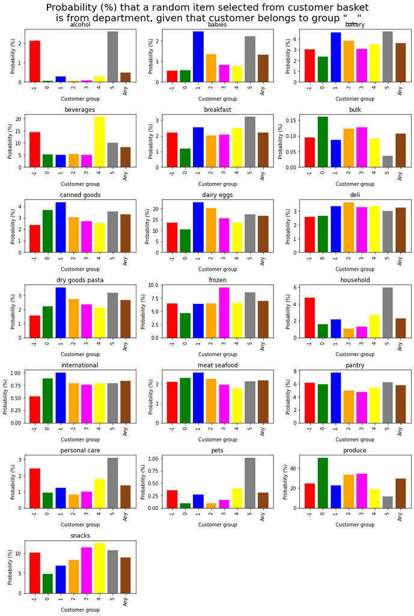

```python
t=get_probabilities_given_group()
t
```

Finally, the lift of each customer group is also presented for each supermarket department, as shown in the table below.

```python
t/t.iloc[-1]
```

| customer_group | alcohol | babies | bakery | beverages | breakfast | bulk | canned goods | dairy eggs | deli | dry goods pasta | frozen | household | international | meat seafood | pantry | personal care | pets | produce | snacks |
| --- | --- | --- | --- | --- | --- | --- | --- | --- | --- | --- | --- | --- | --- | --- | --- | --- | --- | --- | --- |
| -1 | 4.360801 | 0.409473 | 0.836183 | 1.736666 | 0.998125 | 0.883007 | 0.716823 | 0.804857 | 0.800244 | 0.584646 | 0.940488 | 2.061611 | 0.633735 | 0.963879 | 1.056379 | 1.739950 | 1.158876 | 0.839063 | 1.139087 |
| 0 | 0.126462 | 0.423626 | 0.645844 | 0.621969 | 0.533403 | 1.490196 | 1.110613 | 0.630274 | 0.824521 | 0.835449 | 0.673456 | 0.703149 | 1.061057 | 1.057436 | 1.024229 | 0.673743 | 0.312702 | 1.712382 | 0.532081 |
| 1 | 0.591373 | 1.843360 | 1.264574 | 0.604943 | 1.160364 | 0.803739 | 1.320217 | 1.370497 | 1.038856 | 1.337012 | 0.928097 | 0.931352 | 1.205935 | 1.186081 | 1.335992 | 0.885787 | 0.886308 | 0.769048 | 0.763478 |
| 2 | 0.131071 | 1.018572 | 1.058809 | 0.657809 | 0.918146 | 1.134220 | 0.920358 | 1.200526 | 1.129127 | 1.018718 | 0.930636 | 0.453336 | 0.948955 | 1.039017 | 0.852274 | 0.581301 | 0.319345 | 1.124238 | 0.925243 |
| 3 | 0.185670 | 0.623371 | 0.842816 | 0.609166 | 0.951578 | 1.181865 | 0.823412 | 0.924050 | 1.020376 | 0.881846 | 1.381451 | 0.555331 | 0.905971 | 0.900960 | 0.821369 | 0.711691 | 0.544707 | 1.158104 | 1.283538 |
| 4 | 0.580650 | 0.580197 | 0.968188 | 2.495920 | 1.124273 | 0.856526 | 0.772744 | 0.811112 | 1.039029 | 0.786341 | 0.945773 | 1.164533 | 0.942162 | 0.803288 | 0.932318 | 1.274341 | 1.284680 | 0.634285 | 1.409555 |
| 5 | 5.283174 | 1.666084 | 1.286595 | 1.217324 | 1.462669 | 0.337697 | 1.073174 | 1.040207 | 0.926267 | 1.186816 | 1.238323 | 2.611820 | 0.945865 | 0.980967 | 1.069962 | 2.212257 | 3.327986 | 0.390674 | 1.207052 |
| Any | 1.000000 | 1.000000 | 1.000000 | 1.000000 | 1.000000 | 1.000000 | 1.000000 | 1.000000 | 1.000000 | 1.000000 | 1.000000 | 1.000000 | 1.000000 | 1.000000 | 1.000000 | 1.000000 | 1.000000 | 1.000000 | 1.000000 |

## 5. Final conclusions

With the customer segmentation made, one possible way to approach the customers is to give some promotions for products (ex: a discount on certain categories) they are more likely to buy than other customers. As examples:

1. A group that gets discounts in beverages and snacks.
2. A group that gets discounts in alcoholic beverages, household, pets and personal care.
3. A group that gets discounts in baby items.

And so on.

By focusing on unique aspects of these clients it would be possible to retain these customers much more when compared to a campaign with non focused promotions.